# Pemodelan ARIMA - Pendugaan Parameter, Diagnostik Model, dan Peramalan

# Packages

```r
library(ggplot2)
library(tsibble)
library(tseries)
library(MASS)
library(forecast)
library(TSA)
library(TTR)
library(aTSA)
library(graphics)
library(readxl)
```

# Data

Digunakan data Consumer Price Index (CPI) Amerika Serikat (kolom `CPIAUCSL_PC1`) sebanyak 180 observasi bulanan.

```r
datacpi <- read_excel("consumer-price-index-us-1997-2007.xlsx")
str(datacpi)
```

```
## tibble [180 × 2] (S3: tbl_df/tbl/data.frame)
##  $ observation_date: POSIXct[1:180], format: "1993-01-01" "1993-02-01" ...
##  $ CPIAUCSL_PC1    : num [1:180] 3.25 3.25 3.02 3.16 3.22 ...
```

```r
data.ts <- ts(datacpi$CPIAUCSL_PC1)

# Pembagian data latih:uji = 86%:14%
n_total <- length(data.ts)              # 180
n_train <- round(0.86 * n_total)        # 155
n_test  <- n_total - n_train            # 25
```

# Eksplorasi Data

## Plot Data Penuh

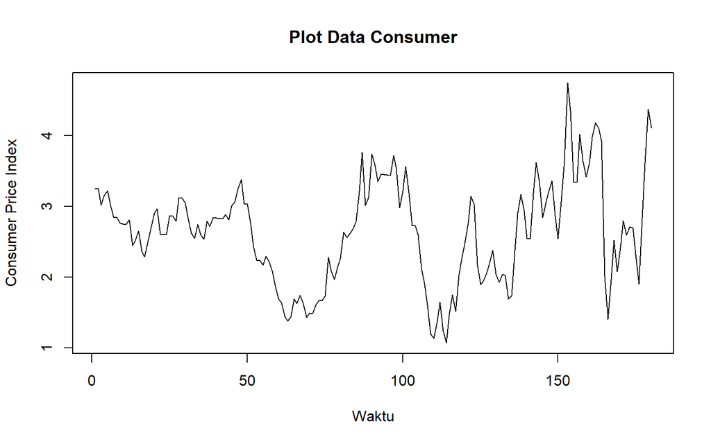

```r
plot.ts(data.ts,
        lty = 1,
        xlab = "Waktu",
        ylab = "Consumer Price Index",
        main = "Plot Data Consumer")
```

Berdasarkan plot data deret waktu, terlihat bahwa data cenderung memiliki trend yang naik. Berdasarkan pola data, pembagian data latih dan data uji ditetapkan dengan proporsi 86%:14%.

## Plot Data Latih

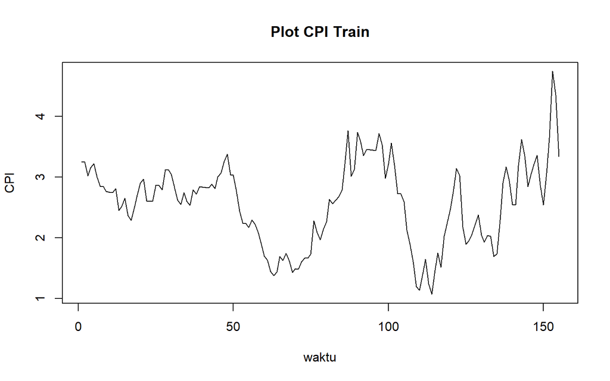

```r
cpitrain <- datacpi$CPIAUCSL_PC1[1:n_train]
train.ts <- ts(cpitrain)
plot.ts(train.ts, lty=1, xlab="waktu", ylab="CPI", main="Plot CPI Train")
```

Berdasarkan plot data deret waktu pada data latih, terlihat bahwa data cenderung memiliki trend yang naik dan cenderung tidak bergerak pada nilai tengah tertentu. Hal ini mengindikasikan bahwa data tidak stasioner dalam rataan.

## Plot Data Uji

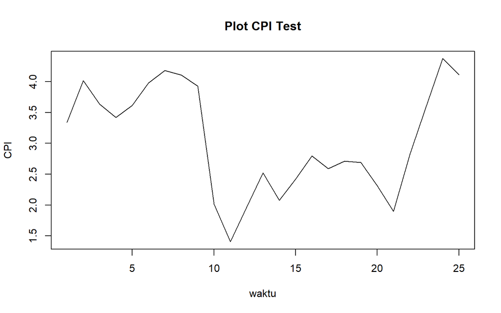

```r
cpitest <- datacpi$CPIAUCSL_PC1[(n_train+1):n_total]
test.ts <- ts(cpitest)
plot.ts(test.ts, lty=1, xlab="waktu", ylab="CPI", main="Plot CPI Test")
```

# Uji Stasioneritas Data

## Plot ACF

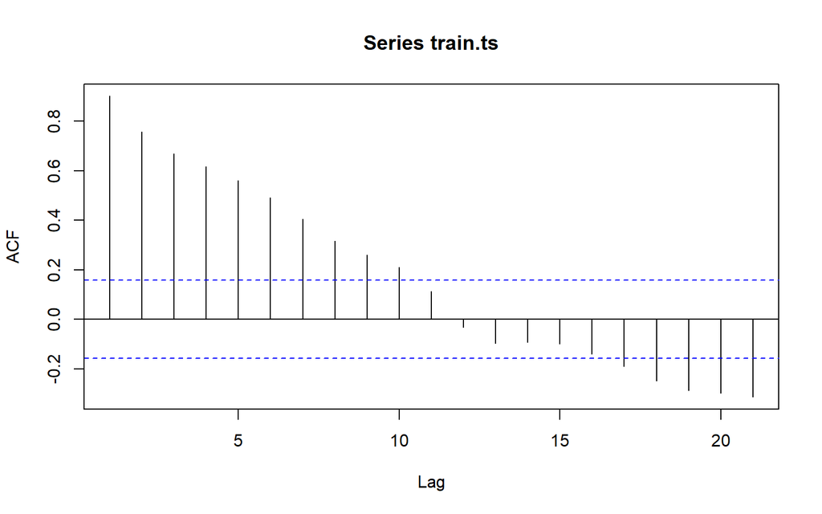

```r
acf(train.ts)
```

Berdasarkan plot ACF, terlihat bahwa plot ACF data menurun secara perlahan (*tails of slowly*). Hal ini juga menjadi indikasi bahwa data tidak stasioner dalam rataan

## Uji ADF

```r
tseries::adf.test(train.ts)
```

```
##
##  Augmented Dickey-Fuller Test
##
## data:  train.ts
## Dickey-Fuller = -2.3219, Lag order = 5, p-value = 0.4422
## alternative hypothesis: stationary
```

$H_0$ : Data tidak stasioner dalam rataan

$H_1$ : Data stasioner dalam rataan

Berdasarkan uji ADF tersebut, didapat *p-value* sebesar 0.4422 yang lebih besar dari taraf nyata 5% sehingga tak tolak $H_0$ dan menandakan bahwa data tidak stasioner dalam rataan. Hal ini sesuai dengan hasil eksplorasi menggunakan plot time series dan plot ACF, sehingga ketidakstasioneran model kedepannya harus ditangani

## Plot Box-Cox

```r
index <- seq_along(train.ts)

# Box-Cox
bc <- boxcox(train.ts ~ index, lambda = seq(0.5, 2, by = 0.1))
```

[figure not shown]

```r
# Nilai lambda optimum (rounded)
lambda_opt <- bc$x[which.max(bc$y)]
lambda_opt
```

```
## [1] 1
```

```r
# Selang kepercayaan 95% untuk lambda
ci_lambda <- bc$x[bc$y > max(bc$y) - 0.5 * qchisq(0.95, df = 1)]

# Batas bawah dan batas atas
ci_lower <- min(ci_lambda)
ci_upper <- max(ci_lambda)

c(Batas_Bawah = ci_lower, Batas_Atas = ci_upper)
```

```
## Batas_Bawah  Batas_Atas
##         0.5         1.5
```

# Penanganan Ketidakstasioneran Data dalam Rataan

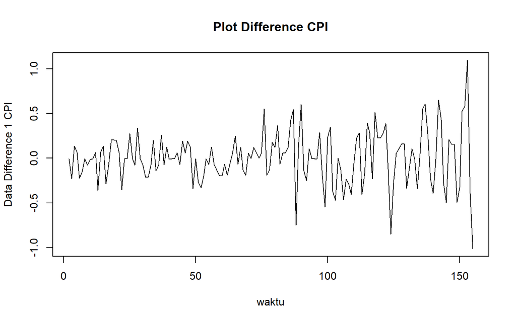

```r
# Dufferencing pertama
train.diff<-diff(train.ts,differences = 1)

# Plot hasil differencing
plot.ts(train.diff, lty=1, xlab="waktu", ylab="Data Difference 1 CPI", main="Plot Difference CPI")
```

Berdasarkan plot data deret waktu, Hasil differencing pertama pada data CPI menunjukkan bahwa data berfluktuasi di sekitar nilai nol tanpa adanya tren yang jelas. Fluktuasi data cenderung lebih besar pada periode akhir, disertai beberapa nilai ekstrem. Differencing pertama membantu menghilangkan tren pada data, tetapi kestasioneran varians dan kemungkinan perubahan volatilitas masih perlu diperiksa lebih lanjut melalui uji stasioneritas dan analisis residual.

## Plot ACF

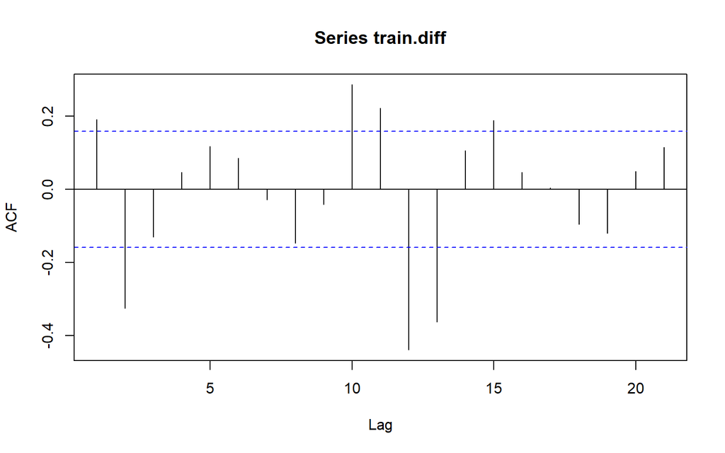

```r
acf(train.diff)
```

## Uji ADF

```r
tseries::adf.test(train.diff)
```

```
##
##  Augmented Dickey-Fuller Test
##
## data:  train.diff
## Dickey-Fuller = -4.4007, Lag order = 5, p-value = 0.01
## alternative hypothesis: stationary
```

$H_0$ : Data tidak stasioner dalam rataan

$H_1$ : Data stasioner dalam rataan

Berdasarkan uji ADF tersebut, didapat *p-value* sebesar 0.01 yang lebih kecil dari taraf nyata 5% sehingga tolak $H_0$ atau data stasioner dalam rataan. Hal ini sesuai dengan hasil eksplorasi menggunakan plot time series dan plot ACF, sehingga dalam hal ini ketidakstasioneran data sudah berhasil ditangani dan dapat dilanjutkan ke pemodelan

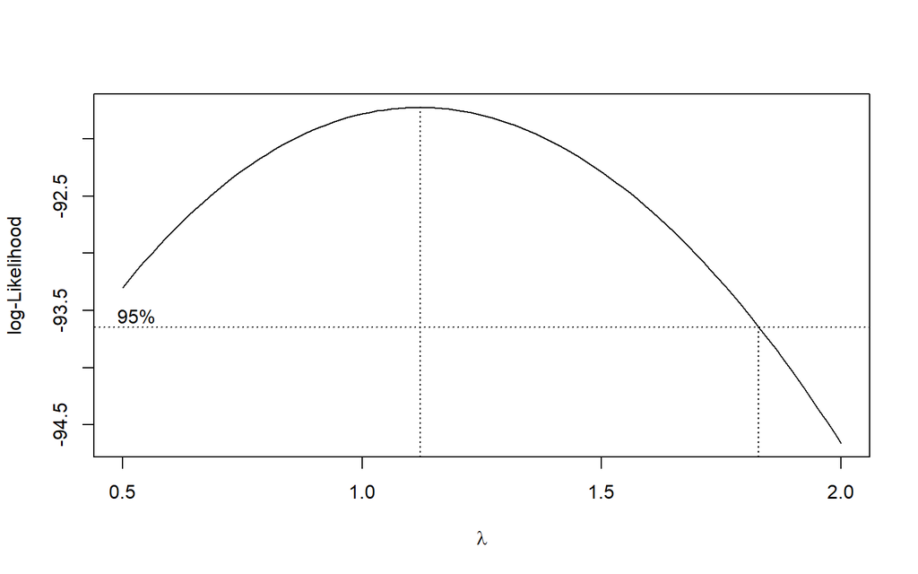

```r
library(MASS)

# 1. Sesuaikan panjang index karena differencing menghilangkan 1 observasi awal
index_diff <- seq_along(train.diff)

# 2. Cek apakah ada nilai negatif/nol. Jika ada, tambahkan konstanta (c)
# agar nilai minimum data menjadi > 0 (misalnya menjadi 1)
min_val <- min(train.diff)

if (min_val <= 0) {
  c <- abs(min_val) + 1
  train.diff_shifted <- train.diff + c
} else {
  train.diff_shifted <- train.diff
}

# 3. Plot Box-Cox pada data yang sudah di-shift
bc_diff <- boxcox(train.diff_shifted ~ index_diff, lambda = seq(0.5, 2, by = 0.1))
```

```r
# 4. Nilai lambda optimum (rounded)
lambda_opt_diff <- bc_diff$x[which.max(bc_diff$y)]
print(paste("Lambda optimum setelah diff:", lambda_opt_diff))
```

```
## [1] "Lambda optimum setelah diff: 1.12121212121212"
```

```r
# 5. Selang kepercayaan 95% untuk lambda
ci_lambda_diff <- bc_diff$x[bc_diff$y > max(bc_diff$y) - 0.5 * qchisq(0.95, df = 1)]

# Batas bawah dan batas atas
ci_lower_diff <- min(ci_lambda_diff)
ci_upper_diff <- max(ci_lambda_diff)

c(Batas_Bawah = ci_lower_diff, Batas_Atas = ci_upper_diff)
```

```
## Batas_Bawah  Batas_Atas
##    0.500000    1.818182
```

# Identifikasi Model

## Plot ACF

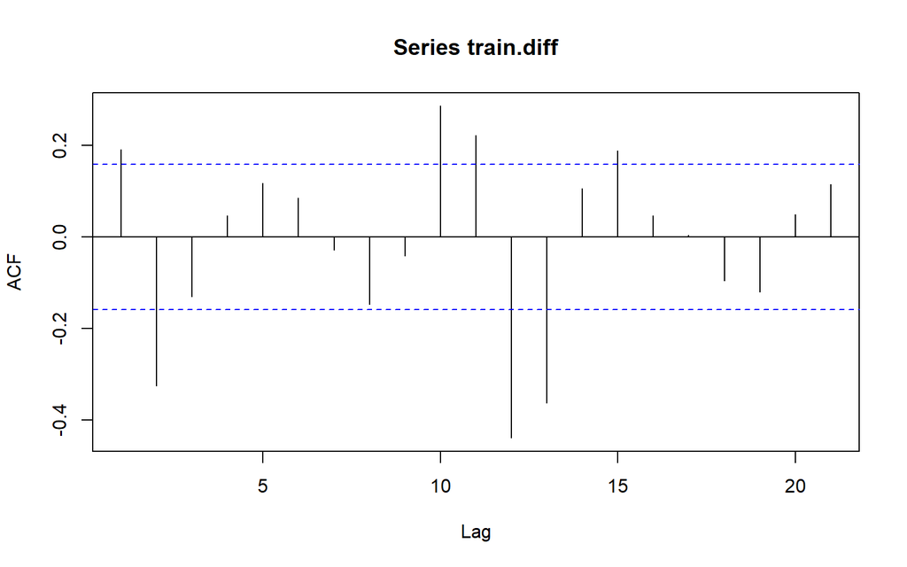

```r
acf(train.diff)
```

Berdasarkan plot tersebut, ACF menunjukkan pola tails off, dengan beberapa spike signifikan pada lag tertentu, termasuk lag 1, 2, 10, 11, 12, dan 15. Pola ini mengindikasikan bahwa orde MA (q) belum dapat ditentukan secara langsung melalui cut-off yang jelas, sehingga diperlukan pertimbangan bersama hasil PACF dan EACF dalam menentukan kandidat model ARIMA.

## Plot PACF

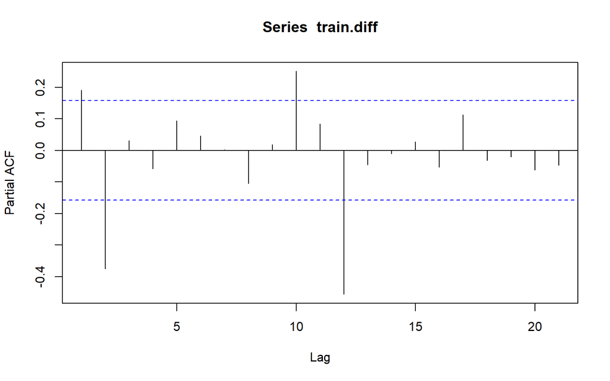

```r
pacf(train.diff)
```

Berdasarkan plot tersebut, PACF menunjukkan pola tails off dengan spike signifikan pada lag 1, 2, 10, dan 12. Pola ini mengindikasikan bahwa orde AR (p) belum dapat ditentukan melalui cut-off yang jelas. Spike pada lag 12 perlu diperiksa lebih lanjut untuk mengetahui kemungkinan pola musiman. Penentuan model ARIMA dilakukan dengan mempertimbangkan hasil ACF, PACF, EACF, serta evaluasi diagnostik residual.

## Plot EACF

```r
eacf(train.diff)
```

```
## AR/MA
##   0 1 2 3 4 5 6 7 8 9 10 11 12 13
## 0 x x o o o o o o o x x  x  x  o
## 1 x x x o o o o o o x o  x  x  o
## 2 o o x o o o o o o o o  x  o  o
## 3 x o o o o o o o o o o  x  x  o
## 4 x o o o o o o o o o o  x  o  x
## 5 x x o o o o o o o o o  x  o  x
## 6 o x x x o o o o o o o  x  x  x
## 7 o x o o o o o o o o o  x  o  o
```

Identifikasi model menggunakan plot EACF dilakukan dengan melihat ujung segitiga pada pola segitiga nol. Dalam hal ini model tentatif yang terbentuk adalah ARIMA(1,1,3), ARIMA(2,1,3), dan ARIMA(3,1,1).

# Pendugaan Parameter Model Tentatif

## ARIMA(0,1,1)

```r
model1.da=Arima(train.diff, order=c(0,0,1),method="ML")
summary(model1.da)
```

```
## Series: train.diff
## ARIMA(0,0,1) with non-zero mean
##
## Coefficients:
##          ma1     mean
##       0.4494  -0.0010
## s.e.  0.0845   0.0322
##
## sigma^2 = 0.07715:  log likelihood = -20.35
## AIC=46.71   AICc=46.87   BIC=55.82
##
## Training set error measures:
##                         ME      RMSE       MAE MPE MAPE      MASE        ACF1
## Training set -0.0002310958 0.2759582 0.2076141 Inf  Inf 0.7850065 -0.08815005
```

```r
lmtest::coeftest(model1.da)
```

```
##
## z test of coefficients:
##
##              Estimate  Std. Error z value  Pr(>|z|)
## ma1        0.44936626  0.08452081  5.3166 1.057e-07 ***
## intercept -0.00097965  0.03216556 -0.0305    0.9757
## ---
## Signif. codes:  0 '***' 0.001 '**' 0.01 '*' 0.05 '.' 0.1 ' ' 1
```

## ARIMA(1,1,0)

```r
model2.da=Arima(train.diff, order=c(1,0,0),method="ML")
summary(model2.da)
```

```
## Series: train.diff
## ARIMA(1,0,0) with non-zero mean
##
## Coefficients:
##          ar1     mean
##       0.2055  -0.0012
## s.e.  0.0820   0.0289
##
## sigma^2 = 0.08269:  log likelihood = -25.59
## AIC=57.19   AICc=57.35   BIC=66.3
##
## Training set error measures:
##                       ME      RMSE       MAE MPE MAPE      MASE       ACF1
## Training set 1.02136e-05 0.2856803 0.2135827 NaN  Inf 0.8075743 0.07794496
```

```r
lmtest::coeftest(model2.da)
```

```
##
## z test of coefficients:
##
##             Estimate Std. Error z value Pr(>|z|)
## ar1        0.2054978  0.0819539  2.5075  0.01216 *
## intercept -0.0011585  0.0289393 -0.0400  0.96807
## ---
## Signif. codes:  0 '***' 0.001 '**' 0.01 '*' 0.05 '.' 0.1 ' ' 1
```

## ARIMA(1,1,1)

```r
model3.da=Arima(train.diff, order=c(1,0,1),method="ML")
summary(model3.da)
```

```
## Series: train.diff
## ARIMA(1,0,1) with non-zero mean
##
## Coefficients:
##           ar1     ma1    mean
##       -0.4007  0.7582  0.0005
## s.e.   0.2332  0.1831  0.0274
##
## sigma^2 = 0.07513:  log likelihood = -17.84
## AIC=43.68   AICc=43.94   BIC=55.82
##
## Training set error measures:
##                         ME      RMSE       MAE MPE MAPE      MASE        ACF1
## Training set -0.0002689717 0.2714157 0.2058522 Inf  Inf 0.7783444 -0.03582245
```

```r
lmtest::coeftest(model3.da)
```

```
##
## z test of coefficients:
##
##              Estimate  Std. Error z value  Pr(>|z|)
## ar1       -0.40070395  0.23321447 -1.7182   0.08576 .
## ma1        0.75817681  0.18310025  4.1408 3.461e-05 ***
## intercept  0.00053955  0.02743275  0.0197   0.98431
## ---
## Signif. codes:  0 '***' 0.001 '**' 0.01 '*' 0.05 '.' 0.1 ' ' 1
```

## ARIMA(1,1,3)

```r
model4.da=Arima(train.diff, order=c(1,0,3),method="ML")
summary(model4.da)
```

```
## Series: train.diff
## ARIMA(1,0,3) with non-zero mean
##
## Coefficients:
##           ar1     ma1      ma2      ma3    mean
##       -0.2350  0.5318  -0.2422  -0.2090  0.0023
## s.e.   0.4832  0.4746   0.1506   0.1698  0.0187
##
## sigma^2 = 0.07208:  log likelihood = -13.65
## AIC=39.29   AICc=39.87   BIC=57.52
##
## Training set error measures:
##                        ME      RMSE       MAE MPE MAPE     MASE         ACF1
## Training set -0.000534462 0.2640904 0.2015086 NaN  Inf 0.761921 -0.002335647
```

```r
lmtest::coeftest(model4.da)
```

```
##
## z test of coefficients:
##
##             Estimate Std. Error z value Pr(>|z|)
## ar1       -0.2350454  0.4832384 -0.4864   0.6267
## ma1        0.5317791  0.4745575  1.1206   0.2625
## ma2       -0.2422224  0.1506023 -1.6084   0.1078
## ma3       -0.2090008  0.1698093 -1.2308   0.2184
## intercept  0.0022972  0.0187140  0.1228   0.9023
```

## ARIMA(2,1,3)

```r
model5.da=Arima(train.diff, order=c(2,0,3),method="ML")
summary(model5.da)
```

```
## Series: train.diff
## ARIMA(2,0,3) with non-zero mean
##
## Coefficients:
##          ar1      ar2      ma1     ma2     ma3    mean
##       0.6638  -0.9672  -0.4572  0.6359  0.4167  0.0035
## s.e.  0.0304   0.0309   0.0862  0.0907  0.0901  0.0232
##
## sigma^2 = 0.05765:  log likelihood = 0.18
## AIC=13.63   AICc=14.4   BIC=34.89
##
## Training set error measures:
##                         ME     RMSE       MAE MPE MAPE      MASE        ACF1
## Training set -6.110069e-05 0.235382 0.1807322 NaN  Inf 0.6833637 -0.02463794
```

```r
lmtest::coeftest(model5.da)
```

```
##
## z test of coefficients:
##
##             Estimate Std. Error  z value  Pr(>|z|)
## ar1        0.6638067  0.0303518  21.8704 < 2.2e-16 ***
## ar2       -0.9672437  0.0308903 -31.3122 < 2.2e-16 ***
## ma1       -0.4572172  0.0861515  -5.3071 1.114e-07 ***
## ma2        0.6358675  0.0906894   7.0115 2.358e-12 ***
## ma3        0.4166775  0.0901188   4.6236 3.770e-06 ***
## intercept  0.0034886  0.0231923   0.1504    0.8804
## ---
## Signif. codes:  0 '***' 0.001 '**' 0.01 '*' 0.05 '.' 0.1 ' ' 1
```

## ARIMA(3,1,1)

```r
model6.da=Arima(train.diff, order=c(3,0,1),method="ML")
summary(model6.da)
```

```
## Series: train.diff
## ARIMA(3,0,1) with non-zero mean
##
## Coefficients:
##           ar1      ar2      ar3     ma1    mean
##       -0.6565  -0.1555  -0.3302  0.9828  0.0028
## s.e.   0.0831   0.0972   0.0829  0.0272  0.0193
##
## sigma^2 = 0.06891:  log likelihood = -10.6
## AIC=33.19   AICc=33.76   BIC=51.41
##
## Training set error measures:
##                         ME      RMSE       MAE MPE MAPE      MASE         ACF1
## Training set -0.0004835085 0.2582125 0.1992396 NaN  Inf 0.7533417 -0.006669371
```

```r
lmtest::coeftest(model6.da)
```

```
##
## z test of coefficients:
##
##             Estimate Std. Error z value  Pr(>|z|)
## ar1       -0.6565043  0.0831003 -7.9001 2.786e-15 ***
## ar2       -0.1555109  0.0972171 -1.5996    0.1097
## ar3       -0.3302402  0.0829372 -3.9818 6.839e-05 ***
## ma1        0.9827555  0.0271922 36.1410 < 2.2e-16 ***
## intercept  0.0028104  0.0193209  0.1455    0.8843
## ---
## Signif. codes:  0 '***' 0.001 '**' 0.01 '*' 0.05 '.' 0.1 ' ' 1
```

## Ringkasan AIC

```r
model_tentatif <- data.frame(
  Model = c("ARIMA(0,1,1)","ARIMA(1,1,0)","ARIMA(1,1,1)", "ARIMA(1,1,3)",
            "ARIMA(2,1,3)", "ARIMA(3,1,1)"),
  AIC   = c(AIC(model1.da),AIC(model2.da), AIC(model3.da), AIC(model4.da), AIC(model5.da), AIC(model6.da)),
  BIC   = c(BIC(model1.da),BIC(model2.da), BIC(model3.da), AIC(model4.da), BIC(model5.da), BIC(model6.da))
)

model_tentatif
```

[output not shown]

### Interpretasi

Berdasarkan hasil perbandingan, **ARIMA(2,1,3)** memiliki nilai **AIC = 13,63** dan **BIC = 34,89**, yang merupakan nilai terendah dibandingkan seluruh model kandidat. Hal ini menunjukkan bahwa ARIMA(2,1,3) memberikan keseimbangan terbaik antara kecocokan model dan kompleksitas berdasarkan kedua kriteria tersebut.

Pada model ARIMA(2,1,3), parameter **AR(1), AR(2), MA(1), MA(2), dan MA(3) signifikan** pada taraf 5% dengan *p-value* < 0,05. Sementara itu, parameter mean tidak signifikan (*p-value* = 0,8804), sehingga rata-rata perubahan data tidak berbeda signifikan dari nol.

Model ini juga menghasilkan **RMSE sebesar 0,2354** dan **MAE sebesar 0,1807**, yang menunjukkan tingkat kesalahan prediksi pada data training relatif lebih rendah dibandingkan model-model sebelumnya.

> **Kesimpulan:** ARIMA(2,1,3) dipilih sebagai model terbaik berdasarkan nilai **AIC dan BIC terendah**. Seluruh parameter AR dan MA signifikan, sehingga model mampu menangkap pola autoregresif dan moving average pada data. Namun, model tetap perlu melalui **uji diagnostik residual (Ljung-Box)** sebelum digunakan sebagai model akhir.

# Analisis Sisaan

Model terbaik hasil identifikasi kemudian dicek asumsi sisaannya. Sisaan model ARIMA harus memenuhi asumsi normalitas, kebebasan sisaan, dan kehomogenan ragam. Diagnostik model dilakukan secara eksplorasi dan uji formal.

## Eksplorasi Sisaan

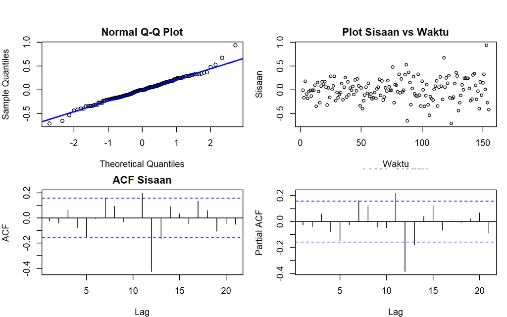

```r
sisaan.da <- model5.da$residuals

par(mfrow = c(2,2),
    mar = c(4,4,2,1),
    oma = c(0,0,2,0))

# Q-Q Plot
qqnorm(sisaan.da, main = "Normal Q-Q Plot")
qqline(sisaan.da, col = "blue", lwd = 2)

# Plot Sisaan vs Waktu
plot(sisaan.da, type = "p",
     main = "Plot Sisaan vs Waktu",
     xlab = "Waktu", ylab = "Sisaan")

# ACF
acf(sisaan.da, main = "ACF Sisaan")

# PACF
pacf(sisaan.da, main = "PACF Sisaan")
```

## Uji Formal

### 1) Sisaan Menyebar Normal

```r
ks.test(sisaan.da,"pnorm")  #tolak H0 > sisaan tidak menyebar normal
```

```
##
##  Asymptotic one-sample Kolmogorov-Smirnov test
##
## data:  sisaan.da
## D = 0.32873, p-value = 7.023e-15
## alternative hypothesis: two-sided
```

Selain dengan eksplorasi, asumsi tersebut dapat diuji menggunakan uji formal. Pada tahapan ini uji formal yang digunakan untuk normalitas adalah uji Kolmogorov-Smirnov (KS). Hipotesis pada uji KS adalah sebagai berikut.

$H_0$ : Sisaan menyebar normal

$H_1$ : Sisaan tidak menyebar normal

### 2) Sisaan saling bebas/tidak ada autokorelasi

```r
Box.test(sisaan.da, type = "Ljung")
```

```
##
##  Box-Ljung test
##
## data:  sisaan.da
## X-squared = 0.095315, df = 1, p-value = 0.7575
```

Selanjutnya akan dilakukan uji formal untuk kebebasan sisaan menggunakan uji Ljung-Box. Hipotesis yang digunakan adalah sebagai berikut.

$H_0$ : Sisaan saling bebas

$H_1$ : Sisaan tidak tidak saling bebas

### 3) Sisaan homogensi

```r
Box.test((sisaan.da)^2, type = "Ljung")
```

```
##
##  Box-Ljung test
##
## data:  (sisaan.da)^2
## X-squared = 0.36619, df = 1, p-value = 0.5451
```

Hipotesis yang digunakan untuk uji kehomogenan ragam adalah sebagai berikut.

$H_0$ : Ragam sisaan homogen

$H_1$ : Ragam sisaan tidak homogen

Berdasarkan uji Ljung-Box terhadap sisaan kuadrat tersebut, didapat *p-value* sebesar 0.5451 yang lebih dari taraf nyata 5% sehingga gagal tolak $H_0$ dan menandakan bahwa ragam sisaan homogen.

### 4) Nilai tengah sisaan sama dengan nol

```r
t.test(sisaan.da, mu = 0, conf.level = 0.95)
```

```
##
##  One Sample t-test
##
## data:  sisaan.da
## t = -0.0032108, df = 153, p-value = 0.9974
## alternative hypothesis: true mean is not equal to 0
## 95 percent confidence interval:
##  -0.0376556  0.0375334
## sample estimates:
##     mean of x
## -6.110069e-05
```

Terakhir, dengan uji-t, akan dicek apakah nilai tengah sisaan sama dengan nol. Hipotesis yang diujikan sebagai berikut.

$H_0$ : nilai tengah sisaan sama dengan 0

$H_1$ : nilai tengah sisaan tidak sama dengan 0

Berdasarkan uji-t tersebut, didapat *p-value* sebesar 0.9974 yang lebih besar dari taraf nyata 5% sehingga gagal tolak $H_0$ dan menandakan bahwa nilai tengah sisaan sama dengan nol.

# Overfitting

Tahapan selanjutnya adalah *overfitting* dilakukan dengan menaikkan orde AR(p) dan MA(q) dari model ARIMA(2,1,3). Kandidat model *overfitting* adalah ARIMA(3,1,3) dan ARIMA(2,1,4).

```r
model7.da=Arima(train.diff, order=c(3,0,3),method="ML")
summary(model7.da)
```

```
## Series: train.diff
## ARIMA(3,0,3) with non-zero mean
##
## Coefficients:
##           ar1      ar2      ar3     ma1     ma2     ma3    mean
##       -0.0309  -0.5244  -0.6894  0.1407  0.2439  0.9427  0.0045
## s.e.   0.1228   0.0837   0.1237  0.0813  0.0645  0.0805  0.0195
##
## sigma^2 = 0.05702:  log likelihood = 1.01
## AIC=13.99   AICc=14.98   BIC=38.28
##
## Training set error measures:
##                         ME     RMSE       MAE MPE MAPE      MASE       ACF1
## Training set -0.0002953137 0.233297 0.1802994 NaN  Inf 0.6817272 0.08174334
```

```r
lmtest::coeftest(model7.da)
```

```
##
## z test of coefficients:
##
##             Estimate Std. Error z value  Pr(>|z|)
## ar1       -0.0308695  0.1228125 -0.2514 0.8015401
## ar2       -0.5243655  0.0837429 -6.2616 3.810e-10 ***
## ar3       -0.6893525  0.1237106 -5.5723 2.514e-08 ***
## ma1        0.1406829  0.0813312  1.7298 0.0836745 .
## ma2        0.2439041  0.0645462  3.7788 0.0001576 ***
## ma3        0.9427121  0.0805472 11.7039 < 2.2e-16 ***
## intercept  0.0044849  0.0194932  0.2301 0.8180319
## ---
## Signif. codes:  0 '***' 0.001 '**' 0.01 '*' 0.05 '.' 0.1 ' ' 1
```

```r
model8.da=Arima(train.diff, order=c(2,0,4),method="ML")
summary(model8.da)
```

```
## Series: train.diff
## ARIMA(2,0,4) with non-zero mean
##
## Coefficients:
##          ar1      ar2      ma1     ma2     ma3     ma4    mean
##       1.3462  -0.6719  -1.1589  0.0064  0.5539  0.0150  0.0068
## s.e.  0.1288   0.1208   0.1596  0.1651  0.1586  0.1602  0.0254
##
## sigma^2 = 0.06471:  log likelihood = -7.11
## AIC=30.22   AICc=31.21   BIC=54.52
##
## Training set error measures:
##                         ME      RMSE      MAE  MPE MAPE      MASE         ACF1
## Training set -0.0004442422 0.2485328 0.193698 -Inf  Inf 0.7323883 0.0006703741
```

```r
lmtest::coeftest(model8.da)
```

```
##
## z test of coefficients:
##
##             Estimate Std. Error z value  Pr(>|z|)
## ar1        1.3462059  0.1288335 10.4492 < 2.2e-16 ***
## ar2       -0.6718532  0.1207935 -5.5620 2.667e-08 ***
## ma1       -1.1589305  0.1596011 -7.2614 3.830e-13 ***
## ma2        0.0063969  0.1651192  0.0387 0.9690968
## ma3        0.5538563  0.1586256  3.4916 0.0004801 ***
## ma4        0.0150211  0.1602217  0.0938 0.9253061
## intercept  0.0067952  0.0254367  0.2671 0.7893592
## ---
## Signif. codes:  0 '***' 0.001 '**' 0.01 '*' 0.05 '.' 0.1 ' ' 1
```

Setelah dilakukan pengujian terhadap model dengan orde yang lebih tinggi, nilai AIC yang diperoleh tidak menunjukkan perbaikan dibandingkan model ARIMA(2,1,3). Hal ini menunjukkan bahwa penambahan kompleksitas model tidak memberikan peningkatan kecocokan yang berarti. Oleh karena itu, model terbaik tetap dipilih **ARIMA(2,1,3)** karena memiliki nilai AIC dan BIC terendah di antara model yang dipertimbangkan.

## Model Terbaik : ARIMA(2,1,3)

```r
model5.da=Arima(train.diff, order=c(2,0,3),method="ML")
summary(model5.da)
```

```
## Series: train.diff
## ARIMA(2,0,3) with non-zero mean
##
## Coefficients:
##          ar1      ar2      ma1     ma2     ma3    mean
##       0.6638  -0.9672  -0.4572  0.6359  0.4167  0.0035
## s.e.  0.0304   0.0309   0.0862  0.0907  0.0901  0.0232
##
## sigma^2 = 0.05765:  log likelihood = 0.18
## AIC=13.63   AICc=14.4   BIC=34.89
##
## Training set error measures:
##                         ME     RMSE       MAE MPE MAPE      MASE        ACF1
## Training set -6.110069e-05 0.235382 0.1807322 NaN  Inf 0.6833637 -0.02463794
```

```r
lmtest::coeftest(model5.da)
```

```
##
## z test of coefficients:
##
##             Estimate Std. Error  z value  Pr(>|z|)
## ar1        0.6638067  0.0303518  21.8704 < 2.2e-16 ***
## ar2       -0.9672437  0.0308903 -31.3122 < 2.2e-16 ***
## ma1       -0.4572172  0.0861515  -5.3071 1.114e-07 ***
## ma2        0.6358675  0.0906894   7.0115 2.358e-12 ***
## ma3        0.4166775  0.0901188   4.6236 3.770e-06 ***
## intercept  0.0034886  0.0231923   0.1504    0.8804
## ---
## Signif. codes:  0 '***' 0.001 '**' 0.01 '*' 0.05 '.' 0.1 ' ' 1
```

## Peramalan

Peramalan dilakukan menggunakan fungsi `forecast()` . Contoh peramalan berikut ini dilakukan sebanyak periode data uji (25 periode) ke depan.

```r
# ---FORECAST---
ramalan.da <- forecast::forecast(model5.da, h = length(test.ts))
```

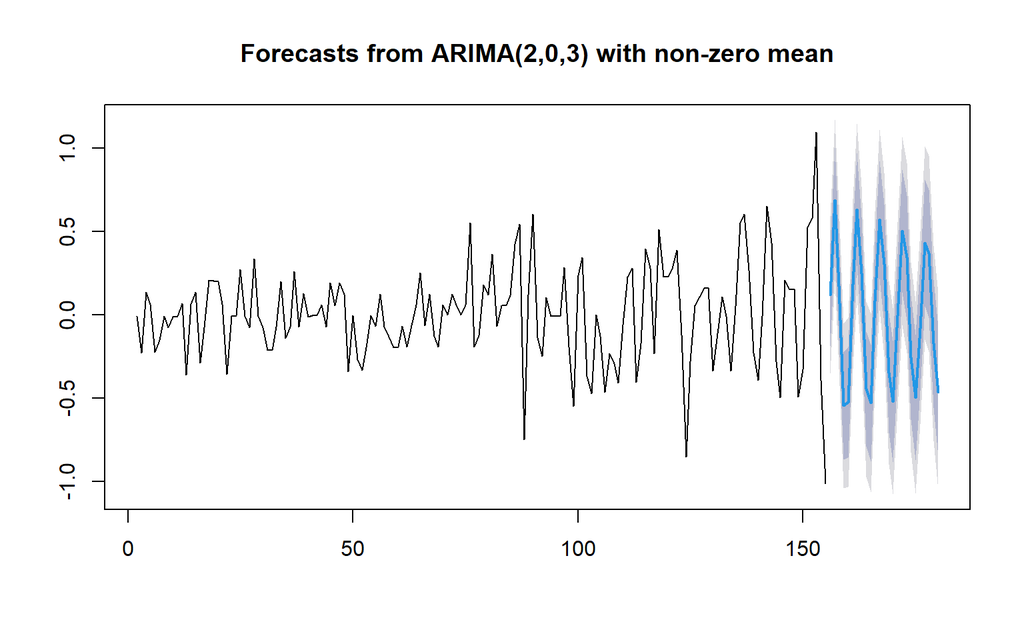

```r
data.ramalan.da <- ramalan.da$mean
plot(ramalan.da)
```

```r
# Inverse differencing
pt_akhir_train <- tail(train.ts, 1)

forecast <- diffinv(data.ramalan.da, differences = 1, xi = pt_akhir_train)
# buang nilai awal (xi) agar hasil sejajar dengan data uji
hasil <- forecast[-1]

# Bandingkan aktual vs forecast
perbandingan.da <- cbind(
  Aktual   = test.ts,
  Forecast = hasil
)

print(head(perbandingan.da, 10))
```

```
## Time Series:
## Start = 1
## End = 10
## Frequency = 1
##     Aktual Forecast
##  1 3.33855 3.458620
##  2 4.01879 4.145069
##  3 3.63825 4.316328
##  4 3.41792 3.770595
##  5 3.61384 3.247232
##  6 3.97727 3.432223
##  7 4.18172 4.065789
##  8 4.10467 4.311970
##  9 3.92657 3.867120
## 10 2.01207 3.338257
```

```r
# Hitung akurasi
akurasi_test <- accuracy(hasil, test.ts)
akurasi_test
```

```
##                  ME     RMSE       MAE       MPE    MAPE      ACF1 Theil's U
## Test set -0.7560011 1.109024 0.9068816 -35.06227 38.8334 0.7346999  2.427893
```

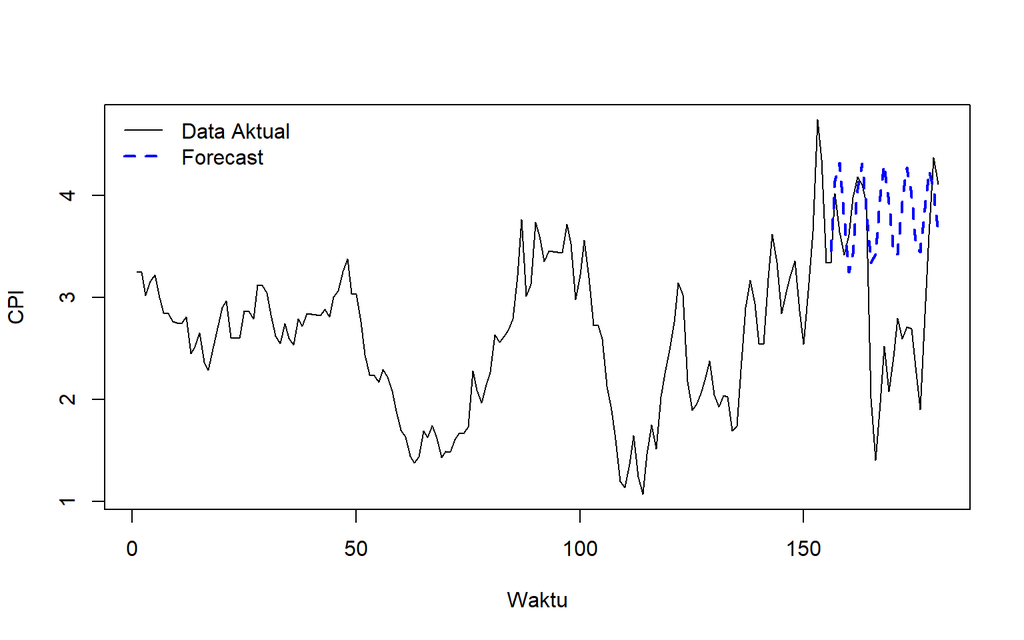

```r
# Plot data
ts.plot(data.ts, col = "black", lty = 1,
        xlab = "Waktu", ylab = "CPI")

# Garis forecast
lines((n_train+1):(n_train+length(hasil)), hasil, col = "blue", lty = 2, lwd = 2)
legend("topleft",
       legend = c("Data Aktual", "Forecast"),
       col = c("black", "blue"),
       lty = c(1,2,3), lwd = c(1,2,1), bty = "n")
```